# Презентация по лабораторной работе №13

Дисциплина: Имитационное моделирование

Лобанова П.И.

Российский университет дружбы народов, Москва, Россия

29 апреля 2025

# Информация

## Докладчик

- Лобанова Полина Иннокентьевна
- Учащаяся на направлении “Фундаментальная информатика и информационные технологии”
- Студентка группы НФИбд-02-22
- polla-2004@mail.ru

# Цель

Выполнить задание для самостоятельного выполнения.

# Схема модели

Заявка (команды программы, операнды) поступает в оперативную память (ОП), затем передается на прибор (центральный процессор, ЦП) для обработки. После этого заявка может равновероятно обратиться к оперативной памяти или к одному из двух внешних запоминающих устройств (B1 и B2). Прежде чем записать информацию на внешний накопитель, необходимо вторично обратиться к центральному процессору, определяющему состояние накопителя и выдающему необходимую управляющую информацию. Накопители (B1 и B2) могут работать в 3-х режимах:

1. B1 — занят, B2 — свободен;
2. B2 — свободен, B1 — занят;
3. B1 — занят, B2 — занят.

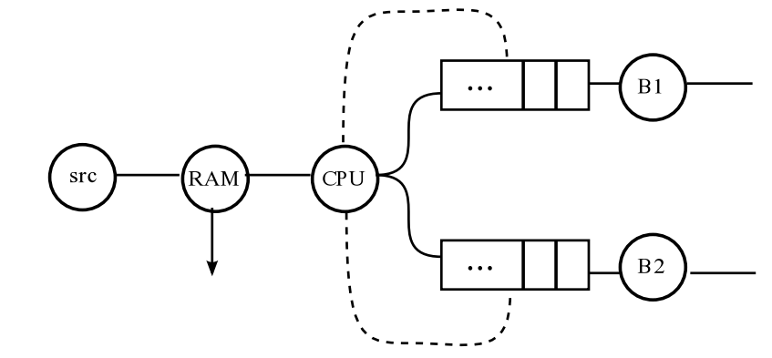

*Схема модели для выполнения домашнего задания*

На схеме:

– src — источник заявок; – B1 и B2 — накопители для хранения заявок; – RAM — оперативная память; – CPU — центральный процессор; – B1, B1 — внешние запоминающие устройства.

# Описание модели

Множество позиций:

P1 — состояние оперативной памяти (свободна / занята);

P2 — состояние внешнего запоминающего устройства B1 (свободно / занято);

P3 — состояние внешнего запоминающего устройства B2 (свободно / занято);

P4 — работа на ОП и B1 закончена;

P5 — работа на ОП и B2 закончена;

P6 — работа на ОП, B1 и B2 закончена;

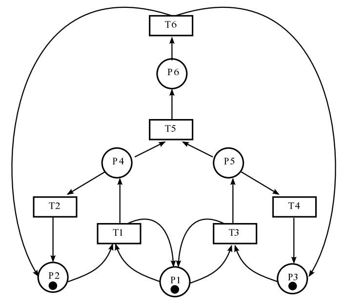

*Сеть для выполнения домашнего задания*

Множество переходов:

T1 — ЦП работает только с RAM и B1;

T2 — обрабатываются данные из RAM и с B1 переходят на устройство вывода;

T3 — CPU работает только с RAM и B2;

T4 — обрабатываются данные из RAM и с B2 переходят на устройство вывода;

T5 — CPU работает только с RAM и с B1, B2;

T6 — обрабатываются данные из RAM, B1, B2 и переходят на устройство вывода.

# Задание

# Выполнение

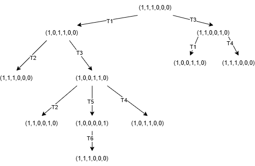

*Дерево достижимости*

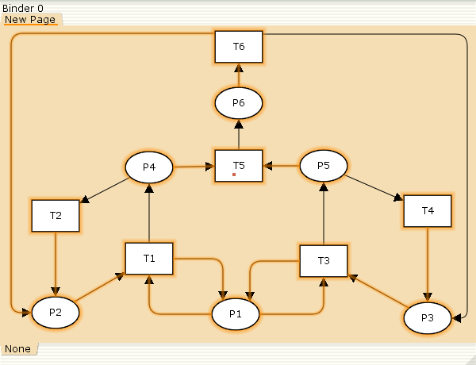

*Схема модели в CPNTools*

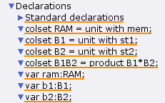

*Декларации*

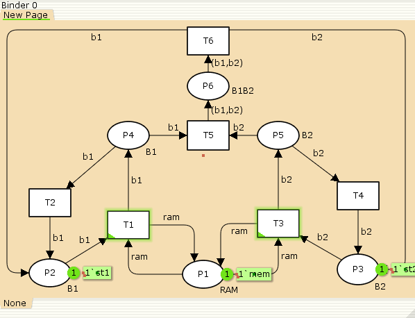

*Полная схема модели в CPNTools*

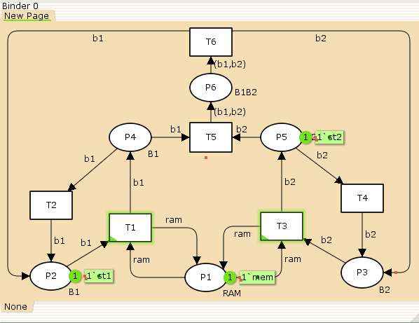

*Запущенная схема модели в CPNTools*

# Вывод

Я выполнила задание для самостоятельного выполнения.